# EC349: Week 5_Lecture 1_R Notebook_CLASSWORK

2023-11-02

##### This notebook is an adaptation of the [Blog: Tidyverse Basics](https://www.dataquest.io/blog/load-clean-data-r-tidyverse/) available at:https://www.dataquest.io/blog/load-clean-data-r-tidyverse/

##### The notebook uses a more recent dataset and includes annotations and other direct references to the EC349 course material to help you, the student, improve your proficiency in R.

November 01, 2023

# [Tidyverse Basics: Load and Clean Data with R tidyverse Tools](https://www.dataquest.io/blog/load-clean-data-r-tidyverse/)

*We’ll load, clean, and prep some Brooklyn real estate data for analysis using R and the tidyverse!*

Messy datasets are everywhere. If you want to analyze data, it’s inevitable that you will need to clean data. In this tutorial, we’re going to take a look at how to do that using R and some nifty tidyverse tools.

The [tidyverse tools](https://www.tidyverse.org/)provide powerful methods to diagnose and clean messy datasets in R. While there’s far more we can do with the tidyverse, in this tutorial we’ll focus on learning how to:

- Import comma-separated values (CSV) and Microsoft Excel flat files into R
- Combine data frames
- Clean up column names
- And more!

The tidyverse is a [collection of R packages](https://www.tidyverse.org/packages/) designed for working with data. The tidyverse packages share a common design philosophy, grammar, and data structures. Tidyverse packages “play well together”. The tidyverse enables you to spend less time cleaning data so that you can focus more on analyzing, visualizing, and modeling data.

## 1. Characteristics of Clean Data and Messy Data

What exactly is clean data? Clean data is accurate, complete, and in a format that is ready to analyze. Characteristics of clean data include data that are:

- Free of duplicate rows/values
- Error-free (e.g. free of misspellings)
- Relevant (e.g. free of special characters)
- The appropriate data type for analysis
- Free of outliers (or only contain outliers have been identified/understood), and
- Follows a “tidy data” structure

Common symptoms of messy data include data that contain:

- Special characters (e.g. commas in numeric values)
- Numeric values stored as text/character data types
- Duplicate rows
- Misspellings
- Inaccuracies
- White space
- Missing data
- Zeros instead of null values

## 2. Motivation

In this blog post, we will work with five property-sales datasets that are publicly available on the New York City Department of Finance Rolling Sales Data website. We encourage you to download the datasets and follow along! Each file contains one year of real estate sales data for one of New York City’s five boroughs. We will work with the following Microsoft Excel files:

- rollingsales_bronx.xls
- rollingsales_brooklyn.xls
- rollingsales_manhattan.xls
- rollingsales_queens.xls
- rollingsales_statenisland.xls

As we work through this blog post, imagine that you are helping a friend launch their home-inspection business in New York City. You offer to help them by analyzing the data to better understand the real-estate market. But you realize that before you can analyze the data in R, you will need to diagnose and clean it first. And before you can diagnose the data, you will need to load it into R!

## 3. Load Data into R with readxl

Benefits of using tidyverse tools are often evident in the data-loading process. In many cases, the tidyverse package readxl will clean some data for you as Microsoft Excel data is loaded into R. If you are working with CSV data, the tidyverse readr, package function read_csv() is the function to use (we’ll cover that later).

##### **PS:** *Use [this link](https://bookdown.org/yihui/rmarkdown-cookbook/font-color.html) for more on changing font color and other formating in R Markdown*.

Let’s look at an example. Here’s how the Excel file for the Brooklyn borough looks:

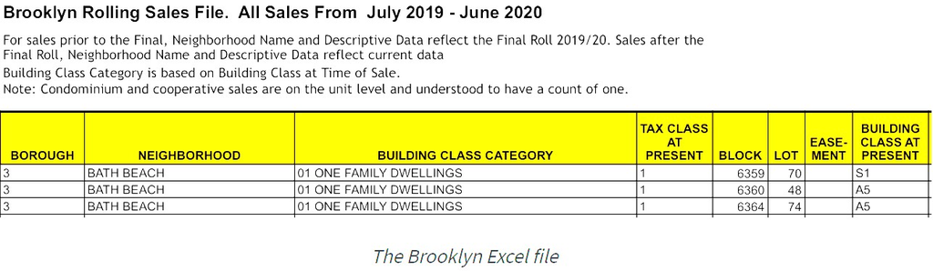

##### **PS:** *Use [this link](https://appsilon.com/r-markdown-tips/#:~:text=To%20insert%20an%20image%2C%20you,looks%20smaller%20by%20default%20though.) for more on inserting images in R Markdown*.

Now let’s load the Brooklyn dataset into R from an Excel file. We’ll use the readxl package. We specify the function argument skip = 4 because the row that we want to use as the header (i.e. column names) is actually row 5. We can ignore the first four rows entirely and load the data into R beginning at row 5. Here’s the code:

*NOTE:* *you will still need to load readxl explicitly, because it is not a core tidyverse package loaded via library(tidyverse). You can install just readxl from CRAN:*

#### ACTIVITY 1

##### Install and load the readxl package from CRAN. Set your working directory using the setwd function.

```r
install.packages("readxl")
```

[output not shown]

```r
library(readxl)
setwd("C:/Users/Harri/OneDrive - University of Warwick/Economics/EC349/Rolling Sales DataSet")
```

#### ACTIVITY 2

##### Insert the code chunk to read the brooklyn dataset. Assign it the name ‘brooklyn’

```r
library(tidyverse)
library(readxl)
setwd("C:/Users/Harri/OneDrive - University of Warwick/Economics/EC349/Rolling Sales DataSet")
brooklyn <- read_excel(rollingsales_brooklyn.xlsx, skip = 4)
```

```
Error: object 'rollingsales_brooklyn.xlsx' not found
```

```
Note:
1. we saved this dataset with the variable name "brooklyn" for future use.
2. My data is stored as xlsx not xls in the online documentation. This is indicative of a change in the original format of the online dataset.
3. Check yours!
```

## 5. Data Types

- NEIGHBORHOOD is “character” type, also known as a string.
- GROSS SQUARE FEET (i.e. the size of the property) is of type “double”, which part of the “numeric” class in R.
- SALE PRICE is also numeric.
- SALE DATE is stored in a format that represents calendar dates and times.

So why does this matter? Because GROSS SQUARE FEET and SALE PRICE are numeric, we can perform arithmetic operations on the data right away. For example, we can calculate the average sale price for all properties:

```r
mean(brooklyn$`SALE PRICE`)
```

[output not shown]

```
Error Alert: Note that as opposed to the online document, we had to put "`" before and after the name "SALE PRICE".

# Attempt running the code without the `.

# Make reference to last lecture for why and how to handle this.
```

## 6. Ready to Plot!

It’s useful that SALE DATE is stored in a format that represents calendar dates and times because this enables us to use a single line of code to make a histogram of property sales by date:

```r
qplot(`SALE DATE`, data = brooklyn, xlab=("Property Sales Trend"))
```

[output not shown]

```
Error Alert: Note the following:
  a) As opposed to the online document, we keep using "`" before and after the name.
  b) Also, notice the warning in the console. How might we address this? Would addressing the conflict when tidyverse is 1st installed/updated have addressed this?
  c) Also notice that the date range is not the same as the online document? How do we fix this? TIP: Browse the data.
  d) Is your output graph also very different from the online one? Can we make the same inference about the COVID-19 pandemic?
```

**How do we solve the problem of the dates?

**HINT:

1. Compare the metadata and data frame output of your own code, and that of the online document.
2. Also See [this section](https://r4ds.had.co.nz/data-import.html#readr-datetimes) of the 1st edition of the recommended text for more on working with dates.
3. Also see this forum for other date issues: [Correctly modify the wrong imported dates](https://community.rstudio.com/t/correctly-modify-the-wrong-imported-dates/139198)
4. Consult this material: [How to Work with Date Ranges Using R](https://help.displayr.com/hc/en-us/articles/360004342976-How-to-Work-with-Date-Ranges-Using-R)

**Note that:** the qplot() [function](https://ggplot2.tidyverse.org/reference/qplot.html) used to make the histogram is from the [ggplot2 package](https://ggplot2.tidyverse.org/index.html), which is a core tidyverse package.

**For more on working with qplot, see:**

1. [qplot: Quick plot with ggplot2 - R software and data visualization](http://www.sthda.com/english/wiki/qplot-quick-plot-with-ggplot2-r-software-and-data-visualization)
2. Also compare to using ggplot. See [this section](https://r4ds.hadley.nz/data-visualize) of the recommended text.

## 7. Comparing to read.csv()

How much has the readxl() [function](https://stat.ethz.ch/R-manual/R-devel/library/utils/html/read.table.html) helped us out? Let’s compare this to the read.csv() function that is built into R. To do this, we downloaded the original Excel file, opened it in the Numbers program on a Mac, and converted the file to CSV. Sure this workflow is not ideal, but it’s not uncommon for analysts to prefer reading in tabular data as a CSV.

#### ACTIVITY 5

##### Download the .xlsx document file on moodel and convert it to .csv and save it to your dataset directory. If it is already there, delete it and try to create it again, with the orginal file name ending with _CSV (e.g., from brooklyn to brooklyn_CSV)

```
I have converted the downloaded document to CSV, and saved directly to working directory. Once done, I commit and push to GitHub. The CSV file is now available to be referenced.
```

#### ACTIVITY 7

##### Load the same .csv dataset using the read_csv command. [!Remember to check the file path].

> > What differences do you observe compared to the readxl function?

## 8. Combining Datasets

If we want to perform data analysis for all five boroughs in New York City it will be helpful to combine the datasets. Also, if the data needs any additional cleaning, it would be great to have to clean the data in only one place instead of five! We’ve verified that the column names are the same across each of the five Excel files. So we can combine the dataframes with the bind_rows() [function](https://dplyr.tidyverse.org/reference/bind.html) from the dplyr package (another tidyverse package!):

```
Recall our new dataset is in xlsx not just xls.

I also always add and extra path when calling.
```

```r
brooklyn <- read_excel("Rolling_Sales_DataSet/rollingsales_brooklyn.xlsx", skip = 4)
bronx <- read_excel("Rolling_Sales_DataSet/rollingsales_bronx.xlsx", skip = 4)
manhattan <- read_excel("Rolling_Sales_DataSet/rollingsales_manhattan.xlsx", skip = 4)
staten_island <- read_excel("Rolling_Sales_DataSet/rollingsales_statenisland.xlsx", skip = 4)
queens <- read_excel("Rolling_Sales_DataSet/rollingsales_queens.xlsx", skip = 4)
```

Next, we want to bind all dataframes into one, save as “NYC_property_sales”:

```r
NYC_property_sales <- bind_rows(brooklyn, bronx, manhattan, staten_island, queens)
```

We call on the glimpse() command again!

```r
glimpse(NYC_property_sales)
```

[output not shown]

## 9.Clean Up Column Names with magrittr Magic!

Now it’s time for one of our favorite data cleaning tricks here at Dataquest!

The column names **contain spaces**, which can be harder to work with in the tidyverse. Also, the column names contain upper-case letters. We don’t want to worry about spaces or remembering to capitalize variable names during our analysis! Let’s quickly clean up the column names using a handy method from the magrittr() [package](https://cran.r-project.org/web/packages/magrittr/vignettes/magrittr.html).

Start by loading the package into memory. Install the package if you need to. The ’magrittr()` package is used in the tidyverse, but we need to load it explicitly to access one of it’s built-in functions.

```r
library(magrittr)
```

We are going to use the **“assignment pipe”** function from the magrittr() package to efficiently update all variable names.

Pipes* are powerful tools that allow R users to chain together multiple operations at once. Pipes also make R code more readable and easier to comprehend. Pipes are used extensively when working with tidyverse tools.

```
*For more on 'Pipes', see Chapter 18 of the 1st edition of the recommended text: <https://r4ds.had.co.nz/pipes.html#pipes>

Also, recall that yesterday, we used a different pipe format: `|>`.
```

Let’s combine the assignment pipe operator with the str_replace_all() function from the tidyverse stringr() package to replace all spaces with underscores. The code for the NYC_property_sales() dataframe looks like this:

```r
colnames(NYC_property_sales) %<>% str_replace_all("\\s", "_") %<>% tolower()
```

So what’s going on here?! Think of the %<>% to mean **“and then update”**. Let’s put this into context.

> The above line of code essentially means:

> ```
> Take the column names from the NYC_property_sales data frame, and then update all column names to replace all spaces with underscores, and then update all column names to lower case.
> ```

That’s a long sentence! But that demonstrates the value of the pipe operator to chain together multiple commands. Let’s take a look at the updated column names:

```r
colnames(NYC_property_sales)
```

## 10. The Pipe Operation

Here’s an example using the commands we’ve learned so far:

```r
NYC_property_sales %>% glimpse()
```

> This roughly translates into:

> ```
> Let’s grab the NYC_property_sales dataframe and then take a glimpse at the data.
> ```

## Recap

Wow, check out everything we covered in this blog post:

- Load Microsoft Excel flat files into R with the read_excel() function from the readxl package
- Import CSV files with the read_csv() function from the readr package
- View dataframe characteristics with the glimpse() function from the magrittrtibble package
- Generate a histogram with the qplot() function from the magrittrggplot2 package
- Combine data frames with the bind_rows() function from the dplyr package
- Clean up column names using functions from the magrittrmagrittr package and the stringr package
- Link commands together with the single-pipe (%>%) from magrittr

As you can see, tidyverse packages are very powerful tools for loading, cleaning, and inspecting data so that you can begin analyzing your data right away! And remember, you can load all of these packages at once with library(tidyverse).